# 项目：TMDB电影数据分析

## 目录

- 简介
- 数据整理
- 探索性数据分析
- 结论

## 简介

> **提示**：本报告对电影的评分和票房的影响因素（电影类型、预算，导演和演员）进行分析，并可视化结果。

```python
#   导入语句。
import pandas as pd
import numpy as np
import matplotlib.pyplot as plt
% matplotlib inline
```

## 数据整理

### 常规属性

```python
# 加载数据并打印几行
df = pd.read_csv('tmdb-movies.csv')
df.head(2)
```

|  | id | imdb_id | popularity | budget | revenue | original_title | cast | homepage | director | tagline | ... | overview | runtime | genres | production_companies | release_date | vote_count | vote_average | release_year | budget_adj | revenue_adj |
| --- | --- | --- | --- | --- | --- | --- | --- | --- | --- | --- | --- | --- | --- | --- | --- | --- | --- | --- | --- | --- | --- |
| 0 | 135397 | tt0369610 | 32.985763 | 150000000 | 1513528810 | Jurassic World | Chris Pratt\|Bryce Dallas Howard\|Irrfan Khan\|Vi... | http://www.jurassicworld.com/ | Colin Trevorrow | The park is open. | ... | Twenty-two years after the events of Jurassic ... | 124 | Action\|Adventure\|Science Fiction\|Thriller | Universal Studios\|Amblin Entertainment\|Legenda... | 6/9/15 | 5562 | 6.5 | 2015 | 1.379999e+08 | 1.392446e+09 |
| 1 | 76341 | tt1392190 | 28.419936 | 150000000 | 378436354 | Mad Max: Fury Road | Tom Hardy\|Charlize Theron\|Hugh Keays-Byrne\|Nic... | http://www.madmaxmovie.com/ | George Miller | What a Lovely Day. | ... | An apocalyptic story set in the furthest reach... | 120 | Action\|Adventure\|Science Fiction\|Thriller | Village Roadshow Pictures\|Kennedy Miller Produ... | 5/13/15 | 6185 | 7.1 | 2015 | 1.379999e+08 | 3.481613e+08 |

2 rows × 21 columns

```python
#   类型，以及是否有缺失数据或错误数据的情况
df.info()
```

```
<class 'pandas.core.frame.DataFrame'>
RangeIndex: 10866 entries, 0 to 10865
Data columns (total 21 columns):
id                      10866 non-null int64
imdb_id                 10856 non-null object
popularity              10866 non-null float64
budget                  10866 non-null int64
revenue                 10866 non-null int64
original_title          10866 non-null object
cast                    10790 non-null object
homepage                2936 non-null object
director                10822 non-null object
tagline                 8042 non-null object
keywords                9373 non-null object
overview                10862 non-null object
runtime                 10866 non-null int64
genres                  10843 non-null object
production_companies    9836 non-null object
release_date            10866 non-null object
vote_count              10866 non-null int64
vote_average            10866 non-null float64
release_year            10866 non-null int64
budget_adj              10866 non-null float64
revenue_adj             10866 non-null float64
dtypes: float64(4), int64(6), object(11)
memory usage: 1.7+ MB
```

### 数据清理（清理列标签，丢空，去重。）

```python
# 清理无关列标签，检查数据
df = df.drop(['imdb_id', 'budget', 'revenue', 'original_title','homepage','tagline','keywords','overview','runtime','production_companies','release_date','vote_count','release_year'], axis=1)
df.head(3)
```

|  | id | popularity | cast | director | genres | vote_average | budget_adj | revenue_adj |
| --- | --- | --- | --- | --- | --- | --- | --- | --- |
| 0 | 135397 | 32.985763 | Chris Pratt\|Bryce Dallas Howard\|Irrfan Khan\|Vi... | Colin Trevorrow | Action\|Adventure\|Science Fiction\|Thriller | 6.5 | 1.379999e+08 | 1.392446e+09 |
| 1 | 76341 | 28.419936 | Tom Hardy\|Charlize Theron\|Hugh Keays-Byrne\|Nic... | George Miller | Action\|Adventure\|Science Fiction\|Thriller | 7.1 | 1.379999e+08 | 3.481613e+08 |
| 2 | 262500 | 13.112507 | Shailene Woodley\|Theo James\|Kate Winslet\|Ansel... | Robert Schwentke | Adventure\|Science Fiction\|Thriller | 6.3 | 1.012000e+08 | 2.716190e+08 |

```python
df.shape
```

```
(10866, 8)
```

```python
# 丢空、去重，查检数据
df = df.dropna().drop_duplicates()
df.info()
```

```
<class 'pandas.core.frame.DataFrame'>
Int64Index: 10731 entries, 0 to 10865
Data columns (total 8 columns):
id              10731 non-null int64
popularity      10731 non-null float64
cast            10731 non-null object
director        10731 non-null object
genres          10731 non-null object
vote_average    10731 non-null float64
budget_adj      10731 non-null float64
revenue_adj     10731 non-null float64
dtypes: float64(4), int64(1), object(3)
memory usage: 754.5+ KB
```

## 探索性数据分析

### # 电影类型、预算，导演和演员对电影评分的影响？

```python
# 不少数据列（假定x）包含由竖线字符（|）分隔的多个数值，考虑创建一个新的DataFrame，包含无字符（|）的x列,和相对应的y列
# 生成新DataFrame后，按照新DataFrame的x旳值分组，计算y平均值，排序取最大的前z个，画出直方图
def p(x,y,z):
# 创建“x”数据列元素列表
    list1 = []
    for i in range(10731):
        list1 += df[x].iloc[i].split('|')
# 创建“x”数据列元素索引列表
    idx1 = range(len(list1))
# 创建“y”数据列元素元素列表
    list2 = []
    for j in range(10731):
        for k in range(len(df[x].iloc[j].split('|'))):
            list2.append(df[y].iloc[j])
# 创建一个新的DataFrame包含列x，y
    items = {x : pd.Series(data = list1, index = idx1),
         y : pd.Series(data = list2, index = idx1)}
    df_x_y = pd.DataFrame(items)
# 按照x分组，求y平均值，降序排列，取前z个，画出直方图,
    df_x_y.groupby(x)[y].mean().sort_values(ascending=False).head(z).plot(kind='bar',figsize=(9,4))
    plt.title('The top ' + str(z) + ' '+ x + ' of ' + y)
    plt.xlabel(x)
    plt.ylabel(y);
```

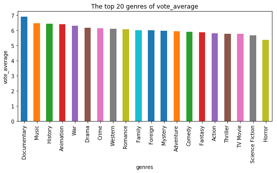

```python
# 电影类型评分排名（总共有20种电影类型）
p('genres','vote_average',20)
```

**结论1：纪录片评分最高，恐怖片评分最低**

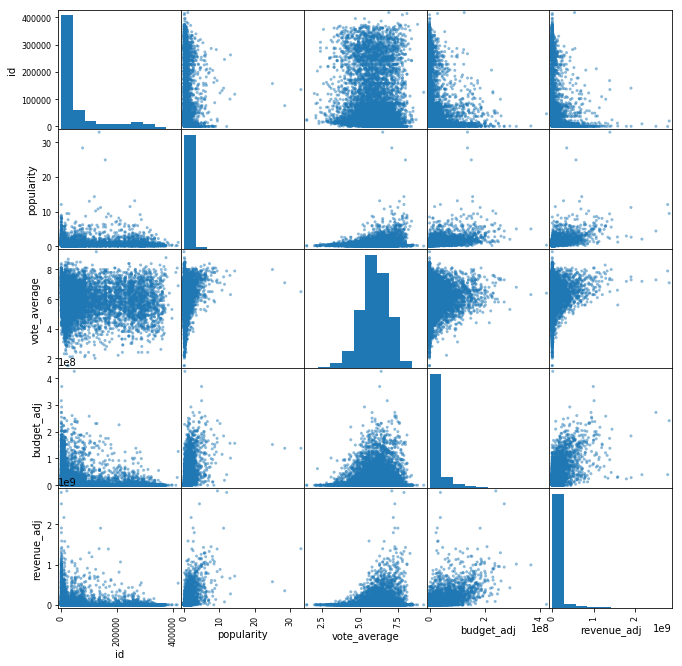

```python
pd.plotting.scatter_matrix(df,figsize=(11,11));
```

```python
df.corr()
```

|  | id | popularity | vote_average | budget_adj | revenue_adj |
| --- | --- | --- | --- | --- | --- |
| id | 1.000000 | -0.009464 | -0.071896 | -0.186980 | -0.137099 |
| popularity | -0.009464 | 1.000000 | 0.217906 | 0.512098 | 0.608384 |
| vote_average | -0.071896 | 0.217906 | 1.000000 | 0.099925 | 0.199418 |
| budget_adj | -0.186980 | 0.512098 | 0.099925 | 1.000000 | 0.645937 |
| revenue_adj | -0.137099 | 0.608384 | 0.199418 | 0.645937 | 1.000000 |

**结论2：预算与电影评分关联很小，预算与电影票房关联较大，电影评分与电影票房关联小**

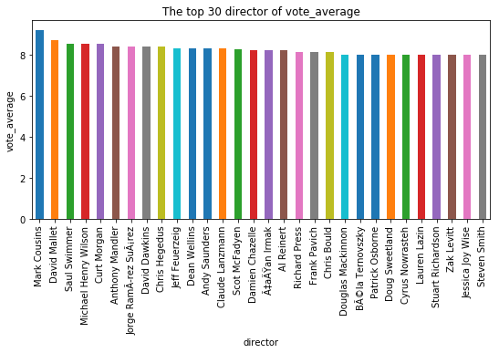

```python
p('director','vote_average',30)
```

**结论3：导演对电影评分影响不明显**

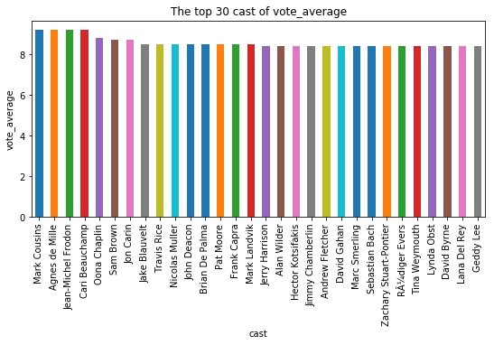

```python
p('cast','vote_average',30)
```

**结论4：演员对电影评分影响也不明显**

### 电影类型、预算，导演和演员对票房的影响？

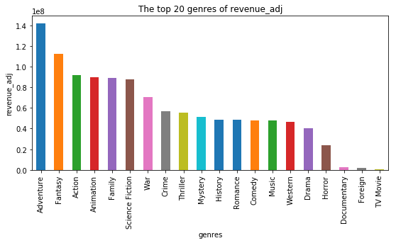

```python
p('genres','revenue_adj',20)
```

**结论5：冒险片票房最高，电视电影票房最低，电影类型对票房影响蛮大的**

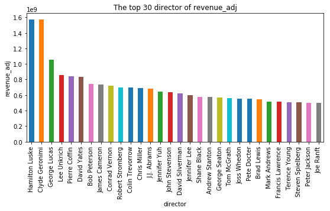

```python
p('director','revenue_adj',30)
```

**结论6：导演对票房影响蛮大，hamilton luske和clyde geronimi影响力比较突出**

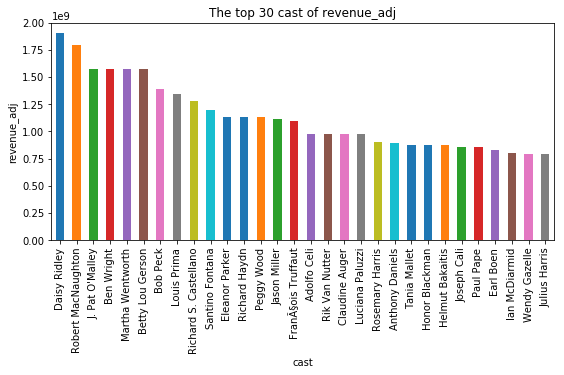

```python
p('cast','revenue_adj',30)
```

**结论7：演员对票房影响蛮大**

## 结论

**1：纪录片评分最高，恐怖片评分最低；** **2：预算与电影评分关联很小，预算与电影票房关联较大，电影评分与电影票房关联小；** **3：导演对电影评分影响不明显；** **4：演员对电影评分影响也不明显；** **5：冒险片票房最高，电视电影票房最低，电影类型对票房影响蛮大的；** **6：导演对票房影响蛮大，其中hamilton luske和clyde geronimi影响力比较突出；** **7：演员对票房影响蛮大；** **局限：票房列存在较多值是0，没有什么好的办法处理。***

```python
from subprocess import call
call(['python', '-m', 'nbconvert', 'Investigate_a_Dataset.ipynb'])
```

```
4294967295
```